# Overfitting

Overfitting is the phenomenon where fitting the observed facts (data) well no longer indicates that we will get a decent out-of-sample error, and may actually lead to the opposite effect.

**The ability to deal with overfitting is what separates professionals from amateurs** in the field of learning from data.

Overfitting literally means "Fitting the data more than is warranted". The main case of overfitting is when you pick the hypothesis with lower $E_{in}$, and it results in higher $E_{out}$ . This means that $E_{in}$ alone is no longer a good guide for learning. A typical overfitting scenario, is in which a complex model uses its additional degrees of freedom to "learn" the noise.

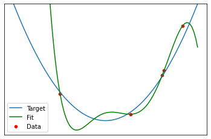

```python
ax.figure
```

## Example: Overfitting with Polynomials

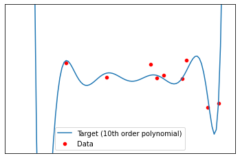

```python
ax.figure
```

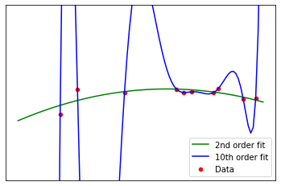

```python
ax.figure
```

|  | 2nd Order | 10th order |
| --- | --- | --- |
| $$E_{in}$$ | 3.23e-7 | 9.85e-31 |
| $$E_{out}$$ | 3.09e-3 | 1.15 |

## Regularization

Regularization is our first weapon to combat overfitting. It constrains the learning algorithm to improve out-of-sample error, especially when noise is present. In the next plot we show the fit improvement when regularization was used.

*Regularization is as much an art as it is a science.*

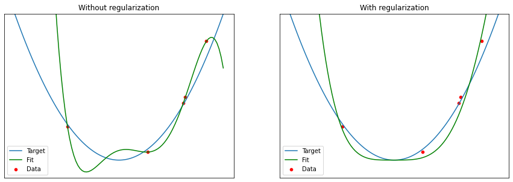

```python
figure
```

### A Soft Order Constraint

Consider a learning model where $\mathcal{H}$ is the set of polynomials in one variable $x \in [-1,1]$. Instead of expressing the polynomials in terms of consecutive powers of $x$, we will express them as a combination of Legendre polynomials in $x$. Legendre polynomials are orthogonal to each other within $x \in [-1, 1]$, and any regular polynomial can be written as a linear combination of Legendre polynomials, just like it can be written as a linear combination of powers of $x$.

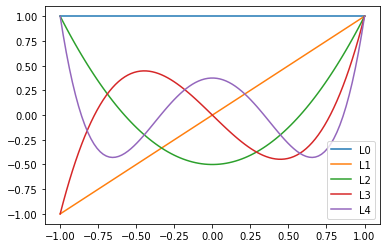

```python
ax.figure
```

Let

$$ \boldsymbol{z} = [1, L_1(x), \cdots, L_Q(x)]^T $$

Since we can build any polynomial of degree Q using Legendre polynomials, we can write our hypothesis set $\mathcal{H}_Q$ as

$$ \mathcal{H}_Q = \left\{ h \; \bigg\vert \; h(x) = \boldsymbol{w}^T \boldsymbol{z} = \sum_{q=0}^Q w_q L_q(x) \right\}_{\boldsymbol{w} \in \mathbb{R}^{Q+1}} $$

Since each $h$ is linear in $\boldsymbol{w}$, we can use the machinery of linear regression to minimize the squared error

$$ E_{in}(\boldsymbol{w}) = \frac{1}{N} \sum_{n=1}^{N} (\boldsymbol{w}^T \boldsymbol{z}_n - y_n)^2 $$

The task of regularization, which results in a final hypothesis $\boldsymbol{w}_{reg}$ instead of the simple $\boldsymbol{w}_{lin}$, is to constrain the learning so as to prevent overfitting the data. We have already seen an example of constraining the learning; the set $\mathcal{H}_2$ can be thought of as a constrained version of $\mathcal{H}_{10}$ in the sense that some of the $\mathcal{H}_{10}$ weights are required to be zero.

Requiring some weights to be 0 is a hard constraint. Instead of requiring some weights to be zero, we can force the weights to be small but not necessarily zero through a softer constraint such as

$$ \sum_{q=0}^Q w_q^2 \leq C $$

The in-sample optimization problem becomes

$$ \min_{\boldsymbol{w}} E_{in}(\boldsymbol{w})\\ s.t. \; \boldsymbol{w}^T \boldsymbol{w} \leq C $$

We can define the soft-order-constrained hypothesis set $\mathcal{H}(C)$ by

$$ \mathcal{H}(C) = \{ h | h(x) = \boldsymbol{w}^T \boldsymbol{z}, \boldsymbol{w}^T \boldsymbol{w} \leq C \} $$

#### Solving for $\boldsymbol{w}_{reg}$

Case 1)

If $\boldsymbol{w}_{lin}^T \boldsymbol{w}_{lin} \leq C$ then $\boldsymbol{w}_{reg} = \boldsymbol{w}_{lin}$ because $\boldsymbol{w}_{lin} \in \mathcal{H}(C)$

Case 2)

If $\boldsymbol{w}_{lin} \notin \mathcal{H}(C)$, then not only $\boldsymbol{w}_{reg}^T \boldsymbol{w}_{reg} \leq C$, but in fact $\boldsymbol{w}_{reg}^T \boldsymbol{w}_{reg} = C$. We can use the Lagrange multipliers strategy to modify the optimization problem to solve

$$ \min_{\boldsymbol{w}} \left[ E_{in}(\boldsymbol{w}) + \lambda (\boldsymbol{w}^T \boldsymbol{w} - C) \right] = \min_{\boldsymbol{w}} \left[ E_{aug}(\boldsymbol{w}) = E_{in}(\boldsymbol{w}) + \lambda \boldsymbol{w}^T \boldsymbol{w} \right] $$

where $E_{aug}(\boldsymbol{w})$ is the *augmented error*, $\lambda$ > 0 is the Lagrange multiplier, which we are going to treat as a free parameter at our disposal and $\boldsymbol{w}^T \boldsymbol{w}$ is the penalty term. The penalty term enforces a tradeoff between making the in-sample error small and making the weights small, and has become known as **weight decay**.

In practice, the choice of the penalty term, is largely heuristic. Finding a perfect penalty term is as difficult as finding a perfect $\mathcal{H}$. It depends on information that, by the very nature of learning, we don't have. However, there are regularizers we can work with that have stood the test of time, such as weight decay. Some forms of regularization work and some do not, depending on the specific application and the data.

## Validation

So far, we have identified overfitting as a problem, noise as a cause, and regularization as a cure. Now, we introduce another cure, called *validation*. One can think of both regularization and validation as attempts at minimizing $E_{out}$ rather than just $E_{in}$. Of course the true $E_{out}$ is not available to us, so we need an estimate of $E_{out}$ based on information available to us in sample.

Regularization attempts to minimize $E_{out}$ by working through the equation below and concocting a heuristic term that emulates the penalty term. Validation, on the other hand, cuts to the chase and estimates the out-of-sample error directly.

$$ E_{out} = E_{in} + \text{overfit penalty} $$

### The Validation Set

The idea of a validation set is almost identical to that of a test set. We remove a subset from the data; this subset is not used in training. We then use this held-out subset to estimate the out-of-sample error. The held-out set is effectively out-of-sample, because it has not been used during the learning.

However, there is a difference between a validation set and a test set. Although the validation set will not be directly used for training, it will be used in making certain choices in the learning process. The minute a set affects the learning process in any way, it is no longer a test set.

[figure not shown]

**Validation Algorithm**

1. Partition the data set $\mathcal{D}$ into a training set $\mathcal{D}_{train}$ of size $(N-K)$ and a validation set $\mathcal{D}_{val}$ of size $K$. Any partitioning method which does not depend on the values of the data points will do.
2. Run the learning algorithm using the training set $\mathcal{D}_{train}$ to obtain a final hypothesis $g^- \in \mathcal{H}$, where the "minus" superscript indicates that some data points were taken out of the training.
3. Compute the validation error for $g^-$ using the validation set $\mathcal{D}_{val}$:

$$ E_{val}(g^-) = \frac{1}{K} \sum_{\boldsymbol{x}_n \in \mathcal{D}_{val}} e(g^{-}(\boldsymbol{x}_n), y_n) $$

The validation error is an unbiased estimate of $E_{out}$ because the final hypothesis $g^-$ was created independently of the data points in the validation set. Indeed, taking the expectation of $E_{val}$ with respect to the data points in $\mathcal{D}_{val}$

$$ \mathbb{E}_{\mathcal{D}_{val}}[E_{val}(g^-)] = \frac{1}{K} \sum_{\boldsymbol{x}_n \in \mathcal{D}_{val}} \mathbb{E}_{\mathcal{D}_{val}}[e(g^{-}(\boldsymbol{x}_n), y_n)]\\ = \frac{1}{K} \sum_{\boldsymbol{x}_n \in \mathcal{D}_{val}} \mathbb{E}_{\boldsymbol{x}_n}[e(g^{-}(\boldsymbol{x}_n), y_n)]\\ = \frac{1}{K} \sum_{\boldsymbol{x}_n \in \mathcal{D}_{val}} E_{out}(g^-) = E_{out}(g^-) $$

Clearly, there is a price to be paid for setting aside $K$ data points to get this unbiased estimate of $E_{out}$: when we set aside more data for validation, there are fewer training data points and so $g^-$ becomes worse, and hence the expected validation error, increases.

If $K$ is neither too small nor too large, $E_{val}$ provides a good estimate of $E_{out}$. A rule of thumb in practice is to set $K=N/5$ (set aside 20% of the data for validation).

### Restoring $\mathcal{D}$

Although the learning curve suggests that taking out $K$ data points for validation and using only $N-K$ for train ing will cost us in terms of $E_{out}$, **we do not have to pay that price!** The purpose of validation is to estimate the out-of-sample performance. This does not mean that we have to output $g^-$ as our final hypothesis.

The primary goal is to get the best possible hypothesis, so we should output $g$, the hypothesis trained on the en tire set $\mathcal{D}$. The secondary goal is to estimate $E_{out}$, which is what validation allows us to do.

If we first train with $N-K$ data points, validate with the remaining $K$ data points and then retrain using all the data to get $g$, the validation error we got will likely a good estimation of $E_{out}(g)$.

So far, we have treated the validation set as a way to estimate $E_{out}$, without involving it in any decisions that affect the learning process. Estimating $E_{out}$ is a useful role by itself a customer would typically want to know how good the final hypothesis is. However, as we will see next , an important role of a validation set is in fact to guide the learning process. That's what distinguishes a validation set from a test set.

### Model Selection

By far, the most important use of validation is for model selection. This could mean the choice between a linear model and a nonlinear model, the choice of the order of polynomial in a model, the choice of the value of a regularization parameter, or any other choice that affects the learning process.

The leap is to realize that validation can be used to estimate the out-of-sample error for more than one model. Suppose we have $M$ models $\mathcal{H}_1, \cdots, \mathcal{H}_M$. Use the training set $\mathcal{D}_{train}$ to learn a final hypothesis $g^-_m$, for each model. Now evaluate each model on the validation set to obtain the validation errors $E_1, \cdots, E_M$, where

$$ E_m = E_{val}(g^-_m); \;\;\; m=1,\cdots,M $$

The validation errors estimate the out-of-sample error $E_{out}(g^-_m)$ for each $\mathcal{H}_m$.

**Is $E_m$ an unbiased estimate for the out of sample error $E_{out}(g^-_m)$?**

It is now a simple matter to select the model with lowest validation error. Let $m^*$ be the index of the model which achieves the minimum validation error. So for $\mathcal{H}_{m^*}$, $E_{m^*} \leq E_m$ for $m=1,\cdots,M$. The model $\mathcal{H}_{m^*}$ is selected based on the validation errors. Note that $E_{m^*}$ is no longer an unbiased estimate of $E_{out}(g^-_{m^*})$. Since we selected the model with minimum validation error, $E_{m^*}$ will have an optimistic bias.

The goal of model selection is to select the best model and output the best hypothesis from that model. Specifically, we want to select the model $m$ for which $E_{out}(g_m)$ will be minimum when we retrain with all the data. Model selection using a validation set relies on the leap of faith that if $E_{out}(g_m)$ is minimum, then $E_{out}(g^-_m)$ is also minimum.

### Cross Validation

Validation relies on the following chain of reasoning,

$$ E_{out}(g) \underset{small K}{\approx} E_{out}(g^-) \underset{large K}{\approx} E_{val}(g^-) $$

which highlights the dilemma we face in trying to select $K$. We would like to choose $K$ as small as possible in order to minimize the discrepancy between $E_{out}(g)$ and $E_{out}(g^-)$; ideally $K=1$. The validation error $E_{val}(g^-)$ will still be an unbiased estimate of $E_{out}(g^-)$ ($g$ is trained on $N-1$ points), but it will be so unreliable as to be useless since it is based on only one data point. This brings us to the *cross validation* estimate of out-of-sample error.

We will focus on the *leave-one-out* version which corresponds to a validation set of size $K=1$, and is also the easiest case to illustrate. More popular versions typically use larger $K$, but the essence of the method is the same.

There are $N$ ways to partition the data into a training set of size $N-1$ and a validation set of size 1. Specifically, let

$$ \mathcal{D}_n = \{ (\boldsymbol{x}_1, y_1), \cdots, (\boldsymbol{x}_{n-1}, y_{n-1}), (\boldsymbol{x}_{n+1}, y_{n+1}), \cdots, (\boldsymbol{x}_N, y_N) \} $$

be the data set $\mathcal{D}$ after leaving out data point $(\boldsymbol{x}_n, y_n)$. Denote the final hypothesis learned from $\mathcal{D}_n$ by $g^-_n$. Let $e_n$ be the error made by $g^-_n$ on its validation set.

$$ e_n = E_{val}(g^-_n) = e(g^-_n(\boldsymbol{x}_n), y_n) $$

The cross validation estimate is the average value of the $e_n$'s,

$$ E_{cv} = \frac{1}{N} \sum_{n=1}^N e_n $$

With cross validation, we have $N$ functions $g^-_1, \cdots, g^-_N$ together with the $N$ error estimates $e_1, \cdots, e_N$. The hope is that these $N$ errors together would be almost equivalent to estimating $E_{out}$ on a reliable validation set of size $N$, while at the same time we managed to use $N-1$ points to obtain each $g^-_n$.

Ideally, we would like to know $E_{out}(g)$. The final hypothesis $g$ is the result of learning on a random data set $\mathcal{D}$ of size $N$. It is almost as useful to know the expected performance of your model when you learn on a data set of size $N$; the hypothesis $g$ is just one such instance of learning on a data set of size $N$. Then the expected performance for a given model is

$$ \bar{E}_{out} = \mathbb{E}_{\mathcal{D}} [E_{out}(g)] $$

The expected value of $E_{cv}$ is exactly $\bar{E}_{out}(N-1)$. This is true because it is true for each individual validation error $e_n$:

$$ \mathbb{E}_{\mathcal{D}}[e_n] = \mathbb{E}_{\mathcal{D}_n} \mathbb{E}_{(\boldsymbol{x}_n, y_n)} [e(g^-_n(\boldsymbol{x}_n), y_n)] = \mathbb{E}_{\mathcal{D}_n} [E_{out}(g^-_n)] = \bar{E}_{out}(N-1) $$

**Why is this important?**

Now that we have our cross validation estimate of $E_{out}$, there is no need to output any of the $g^-_n$, as our final hypothesis. We might as well squeeze every last drop of performance and retrain using the entire data set $\mathcal{D}$, outputting g as the final hypothesis and getting the benefit of going from $N-1$ to $N$ on the learning curve.

With just simple validation and a validation set of size $K=1$, we know that the validation estimate will not be reliable. How reliable is the cross validation estimate $E_{cv}$? We could measure the reliability using the variance of $E_{cv}$ but unfortunately this is not too easy because the dependency on the same datapoints.

**Excersice**

Consider two validation errors $e_n$, $e_m$. Argue why those two errors have dependency on the data point $(\boldsymbol{x}_n, y_n)$.

There are two extremes for this effective size. On the high end is $N$, which means that the cross validation errors are essentially independent. On the low end is $1$, which means that $E_{cv}$ is only as good as any single one of the individual cross validation errors. While one cannot prove anything theoretically, in practice the reliability of $E_{cv}$ is much closer to the higher end.

**What is the price to pay for estimate $E_{out}$ using cross validation?**

**Excersice**

Draw a diagram to show how to use cross validation for model selection.